# Visualization_1

Shan Jiang

9/27/2018

## Lecture Tips

*Dataviz tips*: * 3D is bad, make sure the color is distinguished from the each other; * Never use the pie chart; * Use Color to highlight groups; * Do use the Common Axes; * Good figures are not necessarily the publication quality pictures; Why ggplot: * “Relative” is compared with the base R graphics; * Much easier and much more convinient; * Learning curve for ggplot2/lattice(another package) is needed; learning ggplot: * Stackoverflow; Using ggplot: * data tidy issue is linked affects the ability to visualize

gg = grammar of graphics Basic graph components: * data * aesthetic mappings * geoms

Advanced graph components: *facets* scales *statistics

A graph is built by combining these components

**Git repo for visualizing the data**

- the t means temp and is measured in celsuis degree.

#start a plot

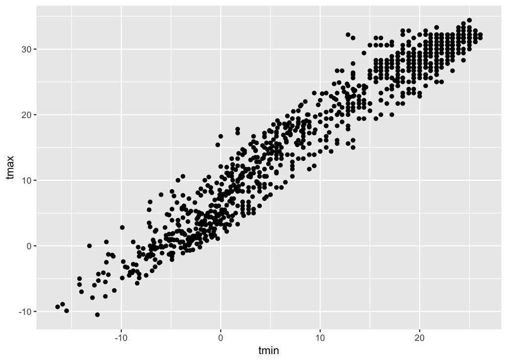

```r
ggplot(weather_df, aes(x = tmin, y = tmax)) +
  geom_point()
```

* you can pipe directly and don’t need to sepcify about the data name

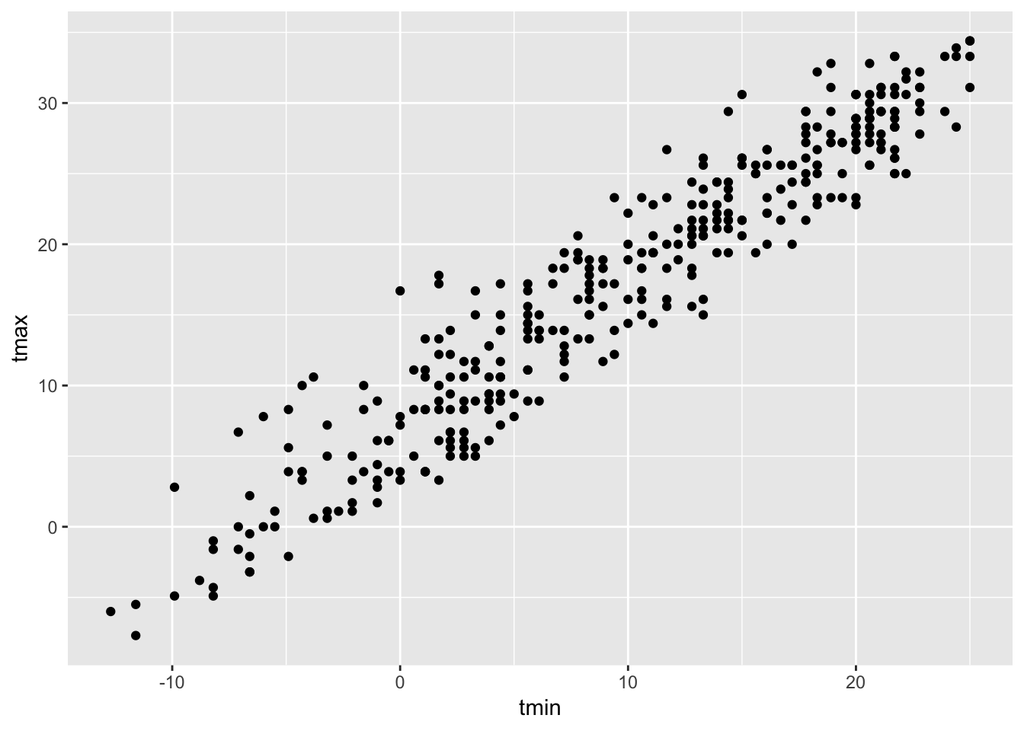

```r
weather_df %>%
  filter(name == "CentralPark_NY") %>%
  ggplot(aes(x = tmin, y = tmax)) %>% +
  geom_point()
```

## More Plot options

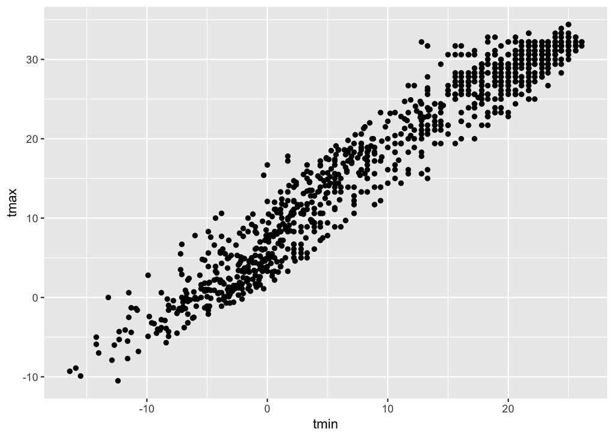

```r
plot_weather =
  weather_df %>%
  ggplot(aes(x = tmin, y = tmax))

plot_weather + geom_point()
```

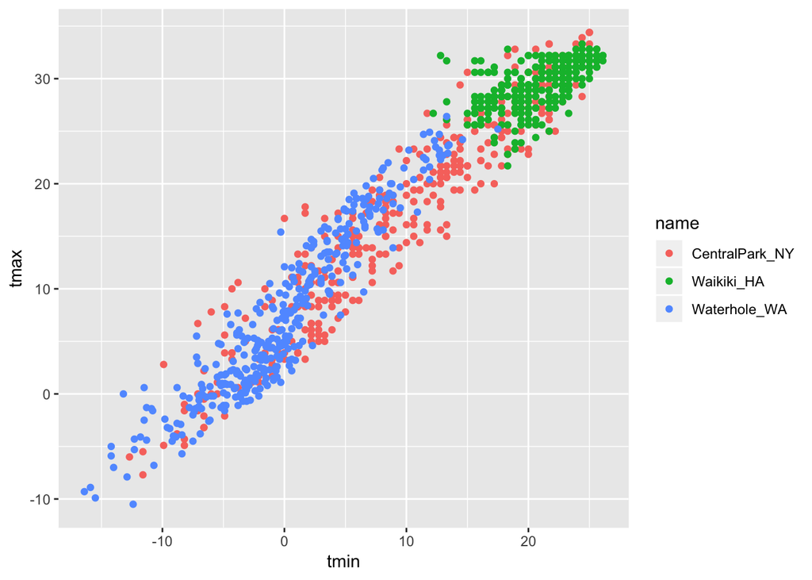

```r
ggplot(weather_df, aes(x = tmin, y = tmax)) +
  geom_point(aes(color = name))
```

## Add a geom _line for the graph

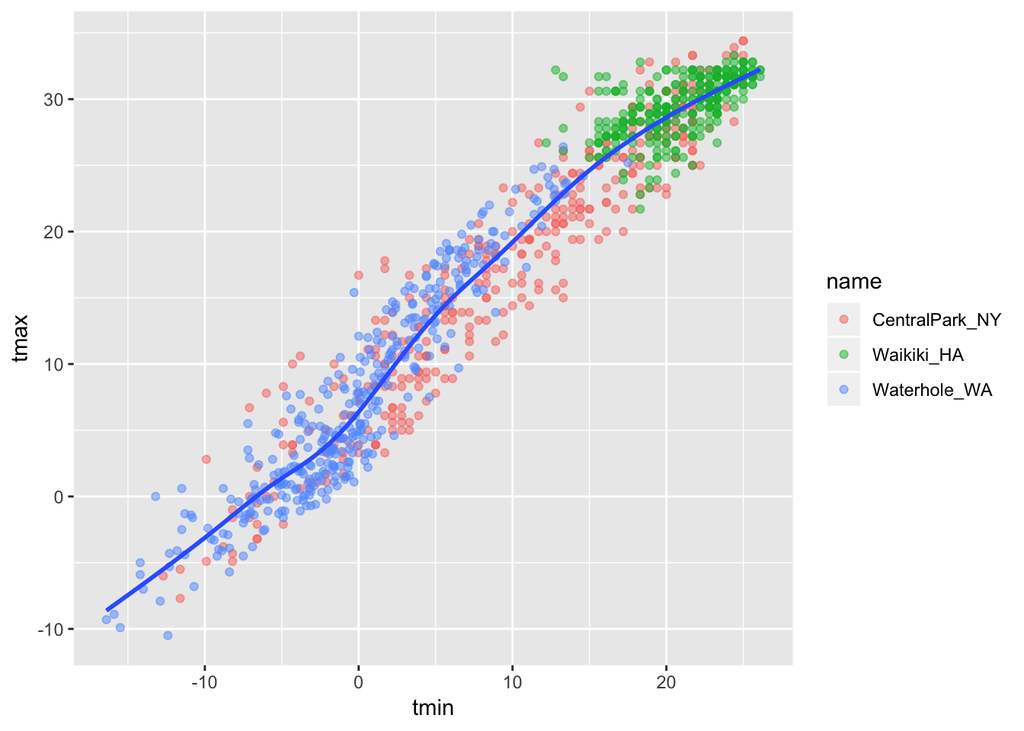

```r
ggplot(weather_df, aes(x = tmin, y = tmax)) +
  geom_point(aes(color = name), alpha = .5) +
  geom_smooth(se = FALSE)
```

```r
geom_smooth()
```

```
## geom_smooth: na.rm = FALSE, se = TRUE
## stat_smooth: na.rm = FALSE, se = TRUE, method = auto, formula = y ~ x
## position_identity
```

- alpha blending level - transparent/ not transparent

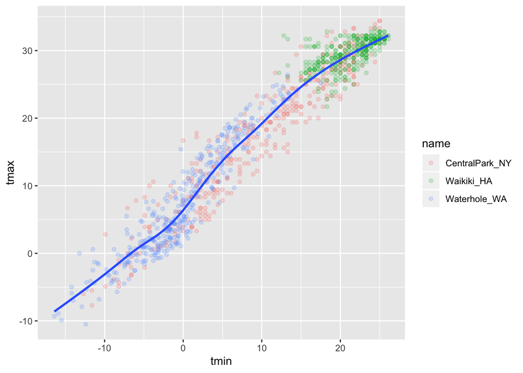

```r
ggplot(weather_df, aes(x = tmin, y = tmax)) +
  geom_point(aes(color = name), alpha = .2) +
  geom_smooth(se = FALSE)
```

* Create every line not a global line

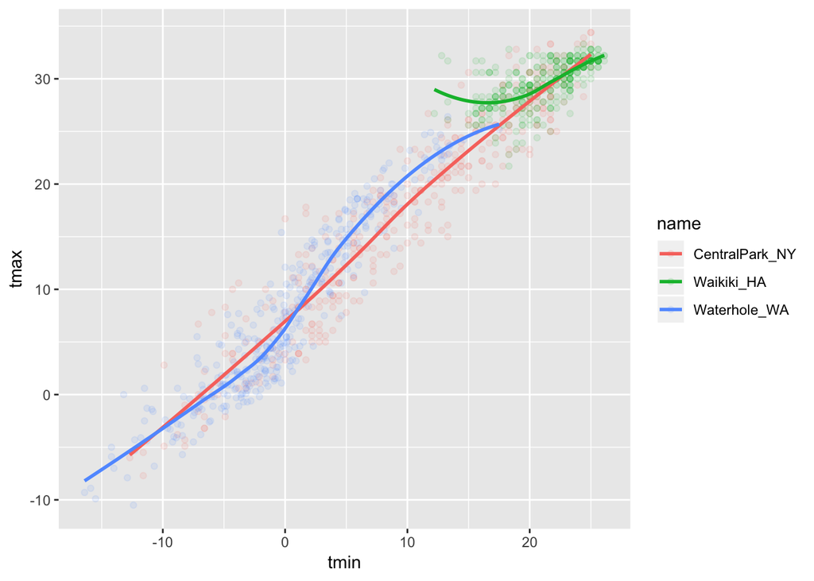

```r
ggplot(weather_df, aes(x = tmin, y = tmax)) +
  geom_point(aes(color = name), alpha = .1) +
  geom_smooth(aes(color = name),se = FALSE)
```

Facetting…

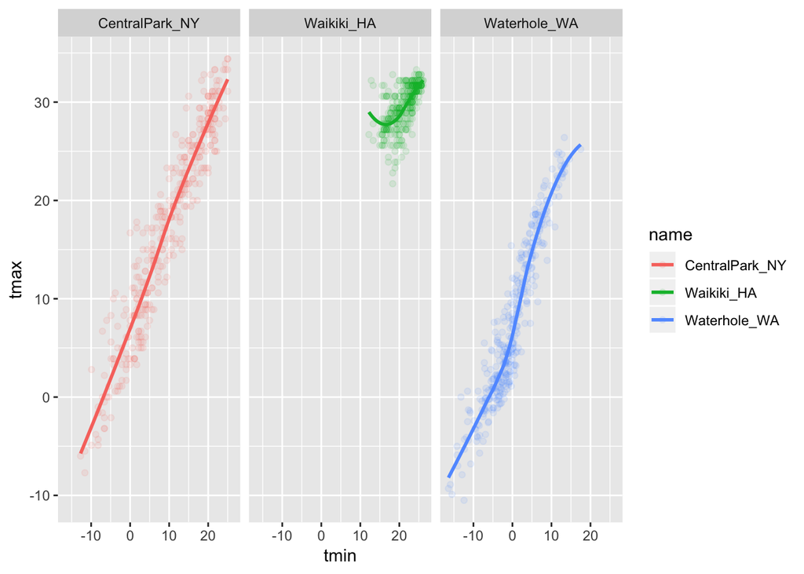

```r
ggplot(weather_df, aes(x = tmin, y = tmax)) +
  geom_point(aes(color = name), alpha = .1) +
  geom_smooth(aes(color = name), se = FALSE) +
 facet_grid(~ name)
```

A more interesting plot / use the date as x.

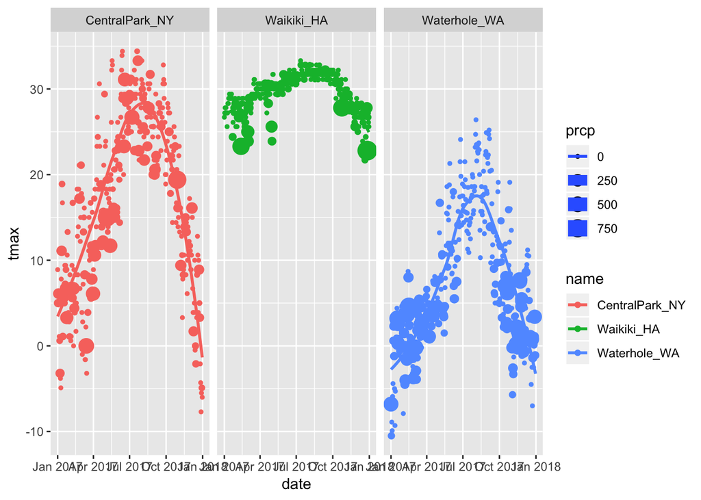

```r
ggplot(weather_df, aes(x = date, y= tmax, color = name, size = prcp)) +
  geom_point() +
  geom_smooth(se = FALSE)+
  facet_grid(~ name)
```

# Create a Geom_hex

[figure not shown]

```r
ggplot(weather_df, aes(x = tmax, y = tmin)) +
  geom_hex()
```

**Tricks in color and definitions for variables in aes**

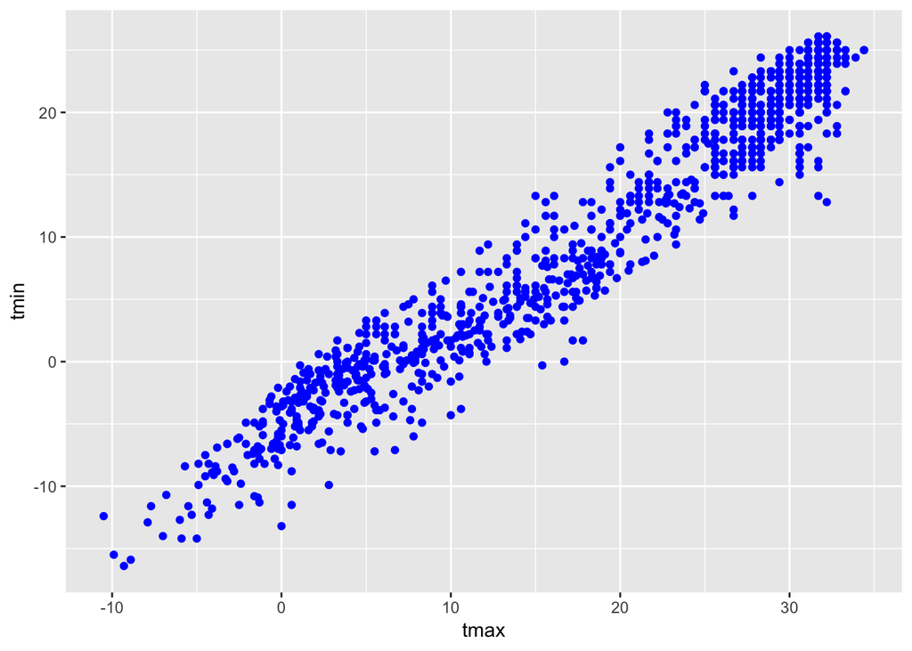

```r
ggplot(weather_df) + geom_point(aes(x = tmax, y = tmin), color = "blue")
```

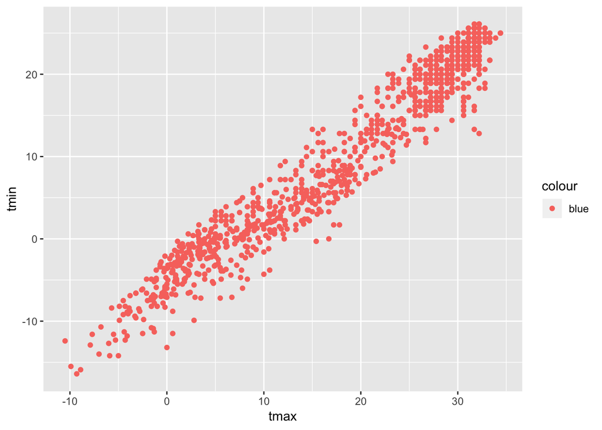

```r
ggplot(weather_df) + geom_point(aes(x = tmax, y = tmin, color = "blue"))
```

##univariate plots

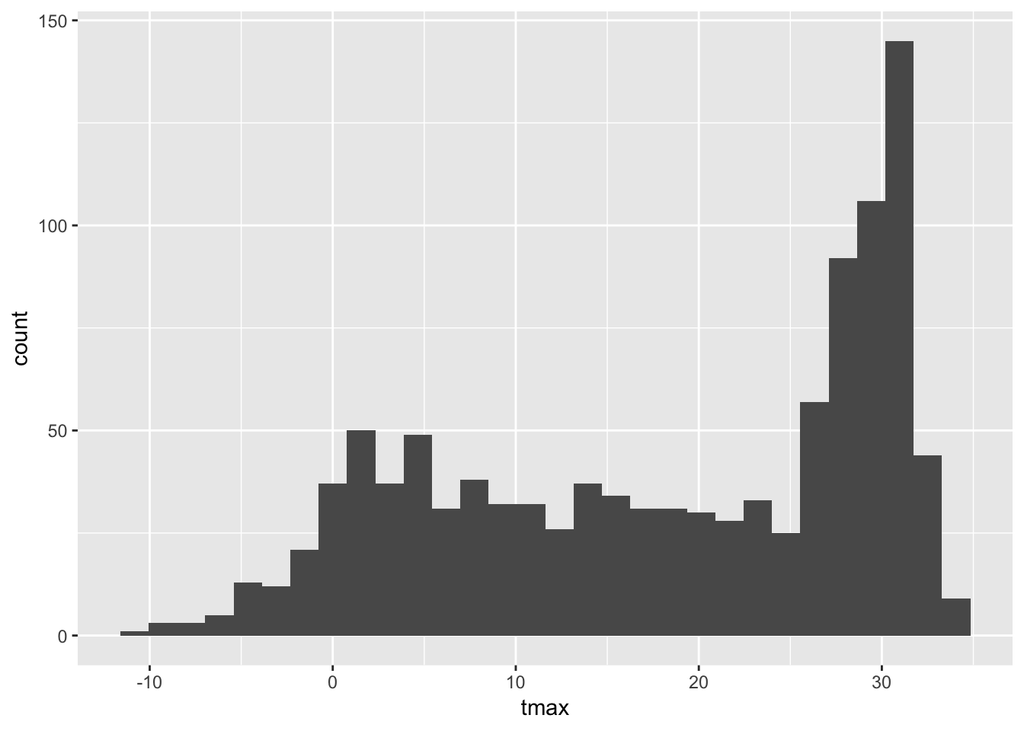

```r
ggplot(weather_df, aes(x = tmax)) +
  geom_histogram()
```

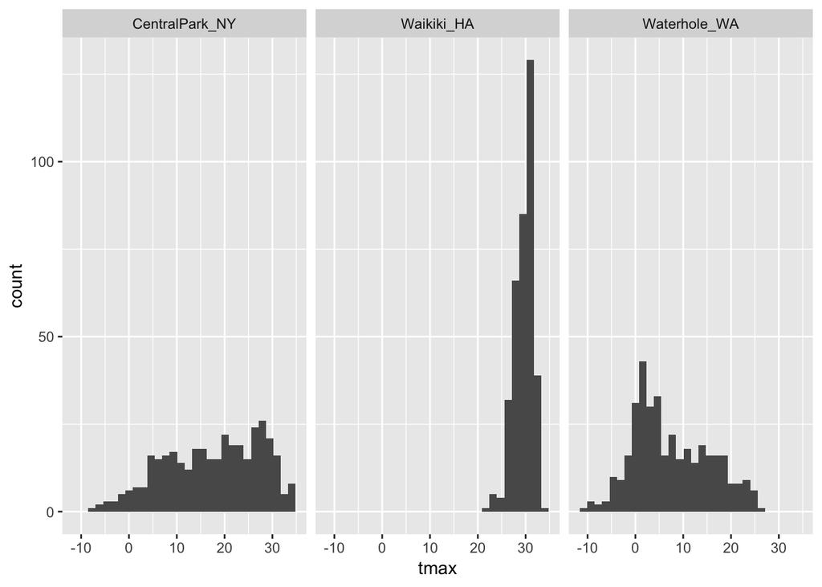

```r
ggplot(weather_df, aes(x = tmax)) +
  geom_histogram()+
  facet_grid(~name)
```

Hist in smooth

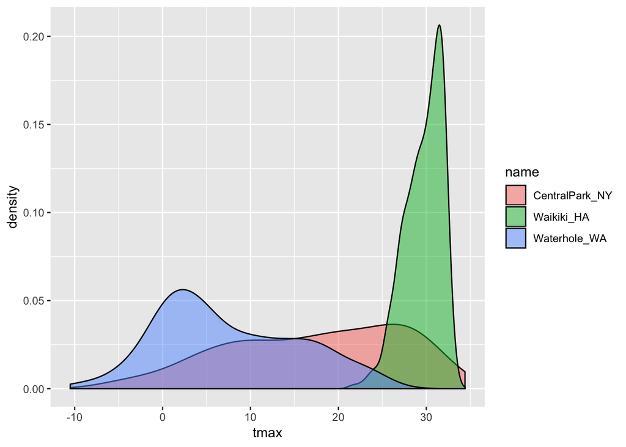

```r
ggplot(weather_df, aes(x = tmax, fill = name)) +
  geom_density(alpha = .5)
```

Boxplots!!

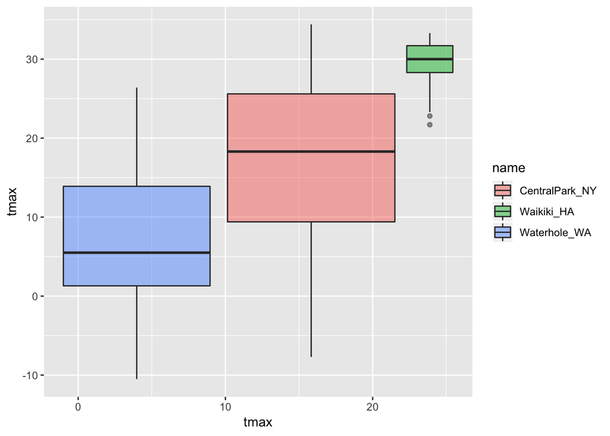

```r
ggplot(weather_df, aes(x = tmax, y =tmax, fill = name)) +
  geom_boxplot(alpha = .5)
```

- violin plots for group comparison

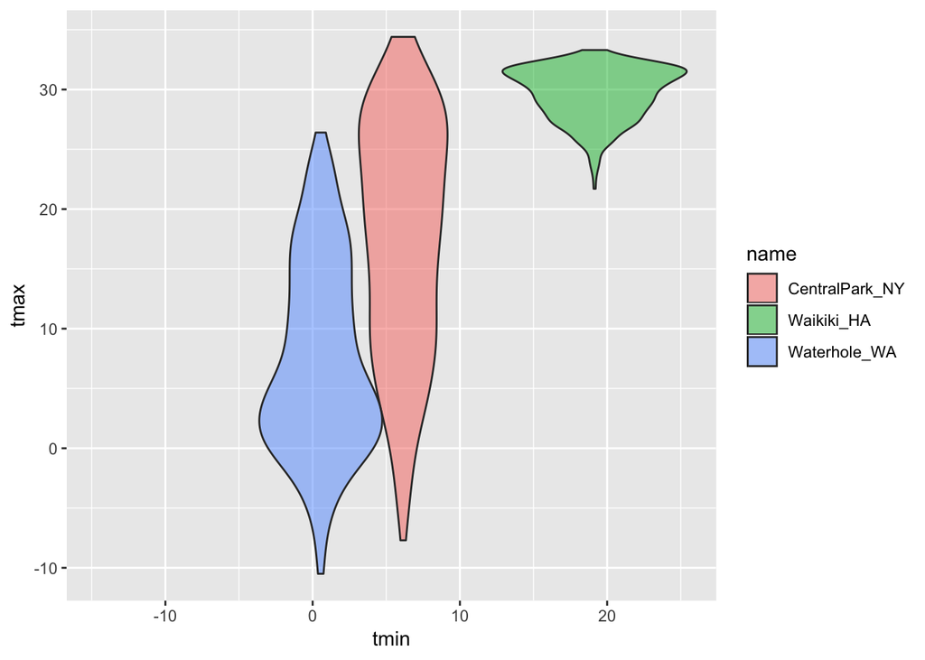

```r
ggplot(weather_df, aes(x = tmin, y = tmax, fill = name)) +
  geom_violin(alpha = .5)
```

ridges plot

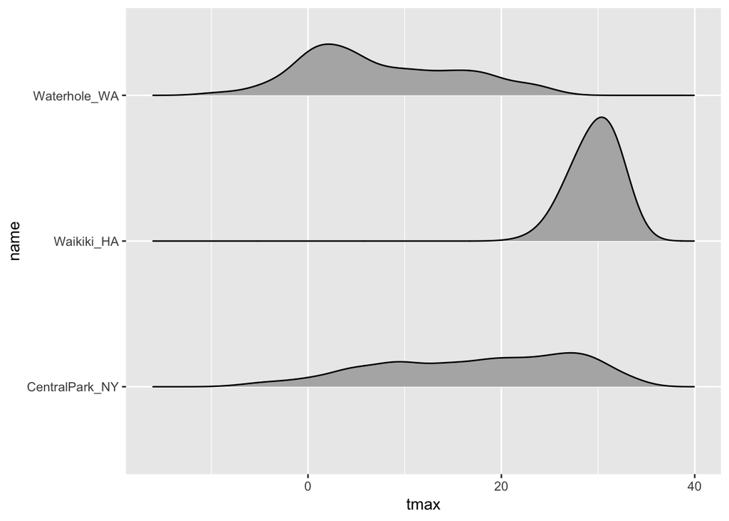

```r
ggplot(weather_df, aes(x = tmax, y = name)) +
  geom_density_ridges(scale = .85)
```

## gg save for saving the document

```r
weather_plot = ggplot(weather_df, aes(x = tmax, y = name)) +
  geom_density_ridges(scale = .85)
ggsave("weather plot.png", weather_plot, width = 8, height = 5)
```

- adjust the file size

```r
knitr::opts_chunk$set(
  fig.width = 6,
  fig.asp = .6,
  out.width = "90%"
)
```